## ITAM

### Maestría en Ciencia de Datos

#### Métodos Lineales Generalizados.

- Profesor:
  - **Luis Enrique Nieto Barajas**
- Alumna:
  - **Gabriela Flores Bracamontes**
- Clave:
  - **160124**
- 19 de septiembre de 2016
- Ejercicio 2
- Descripción:
  - Las utilidades mensuales de una compañía tienen una distribución N($\mu, \sigma^2$). Suponga que una muestra de 10 meses de esta compañía dio como resultado las siguientes utilidades: (212, 207, 210, 196, 223, 193, 196, 210, 202, 221).
  - 1. La incertidumbre sobre la utilidad promedio anual $\mu$ se puede representar por una distribución N(200,40), y la incertidumbre de la desviación estándar de las utilidades mensuales se puede representar mediante una distribución Ga(10,1). Mediante la distribución posterior estima $\mu$ y $\sigma^2$.
  - 2. Utilizando una distribución inicial no informativa, estima mediante la correspondiente distribución inicial $\mu$ y $\sigma^2$ .

### Conclusiones:

En el ejercicio utilizamos 2 modelos, el primero con una distribución inicial informativa con parámetros $\mu$=200 y $\sigma^2$=10; el segundo con una distribución inicial **no** informativa con parámetros $\mu$=0 y $\sigma^2$=0.001; los cuáles nos dieron las siguientes medidas de ajuste:

- Modelo 1
  - **DIC: 76.98607**
  - $\mu$=205.47244
  - $\sigma^2$=10.54300
  - Intervalos $\mu$=(203.6,211) y $\sigma^2$=(9.1480, 15.01525)
- Modelo 2
  - **DIC: 78.46189**
  - $\mu$ =206.70280
  - $\sigma^2$=11.22055
  - Intervalos $\mu$=(204.5,213.9) y $\sigma^2$=(9.1395,18.53050)

Ambas estimaciones se parecen a la $\mu$ y la $\sigma^2$ de los datos pero el mejor ajuste se presentó con el modelo 1 por lo tanto sería mejor elegirlo.

### A continuación se describe el código y se muestran las gráficas y tablas que resultaron del ejercicio 2.

### Definimos el modelo con una inicial informativa

- Las variables son de tipo Normal ($\mu, \tau$)
- f($\mu, \sigma^2$) es nuestra distribución inicial
- Utilizamos el archivo **Eje2_a.txt** para describir nuestro modelo:

  ```bash
  model
  {
  #Likelihood
  for (i in 1:n) {
  x[i] ~ dnorm(mu,tau)
  }
  tau<-1/pow(sig,2)
  #Priors
  #----------
  #Inciso a
  mu ~ dnorm(200,tau0)
  tau0<-1/40
  sig ~ dgamma(10,1)
  #----------
  #Prediction
  x1 ~ dnorm(mu,tau)
  }
  ```

### Definimos los datos, inicializamos y seleccionamos los parámetros a monitorear.

```r
library(R2OpenBUGS)
library(R2jags)
library(ggplot2)
```

```r
#-Working directory-
setwd("E:/itam/2016 Verano/glm/")

#--- Ejemplo 2---
#--Datos
utilidad<-c(212, 207, 210, 196, 223, 193, 196, 210, 202, 221)
n<-length(utilidad)

summary(utilidad)
```

```
##    Min. 1st Qu.  Median    Mean 3rd Qu.    Max.
##   193.0   197.5   208.5   207.0   211.5   223.0
```

```r
sd(utilidad)
```

```
## [1] 10.31719
```

```r
#-Defining data-
data<-list("n"=n,"x"=utilidad)

#-Defining inits-
inits<-function(){list(mu=0,sig=1,x1=0)}

#-Selecting parameters to monitor-
parameters<-c("mu","sig","x1")
```

### Simulamos con el modelo previamente definido y graficamos.

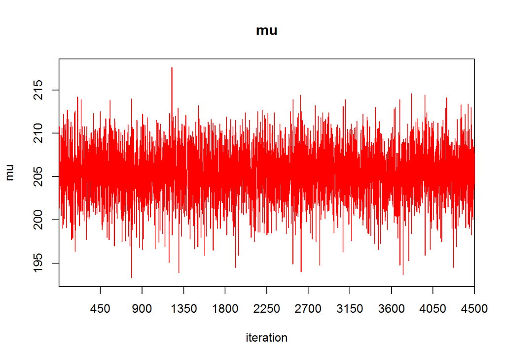

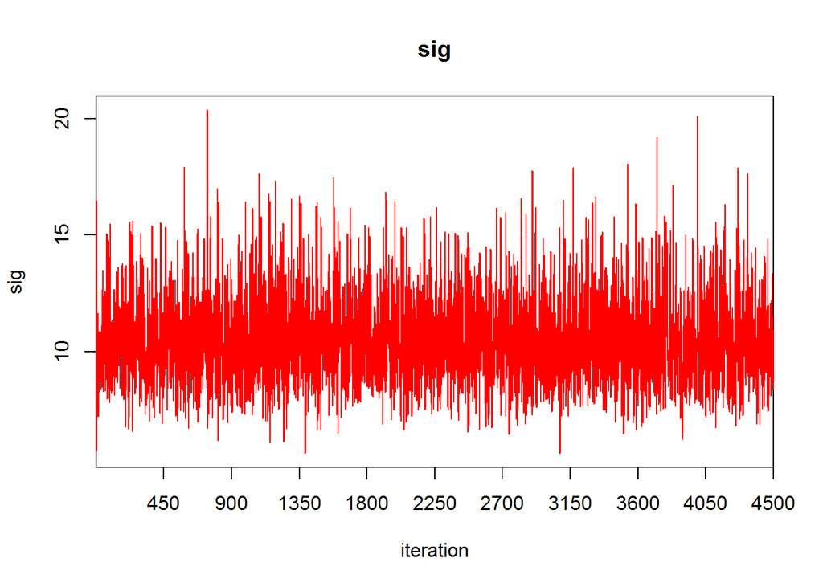

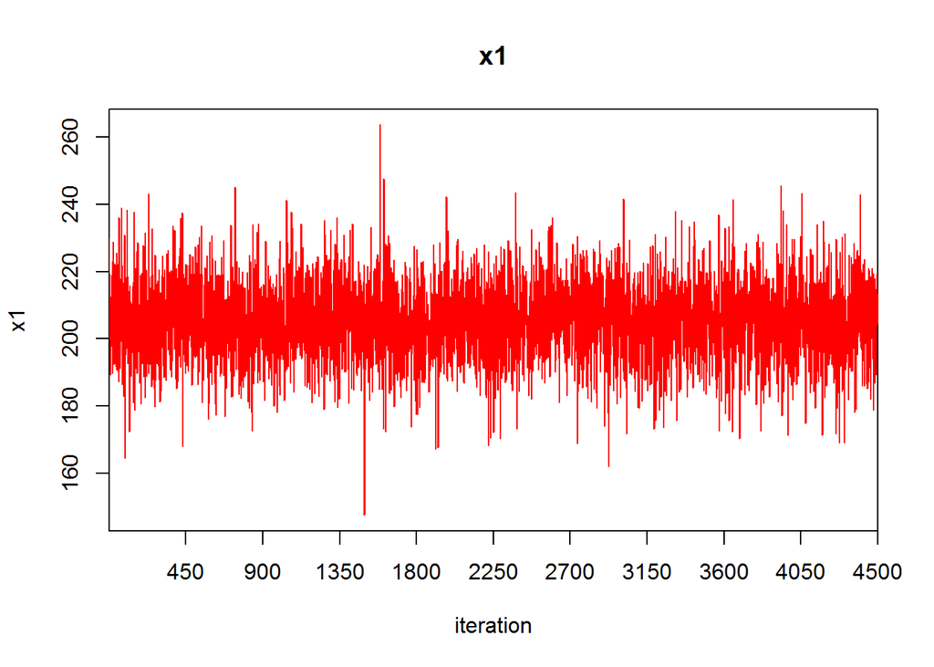

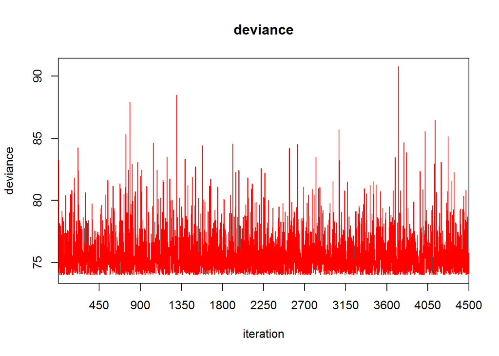

```r
#-Running code-
#OpenBUGS
ej2.sim<-bugs(data,inits,parameters,model.file="Ej2_a.txt",           n.iter=5000,n.chains=1,n.burnin=500)

#-Monitoring chain-

#Traza de la cadena
traceplot(ej2.sim)
```

```r
dev.off()
```

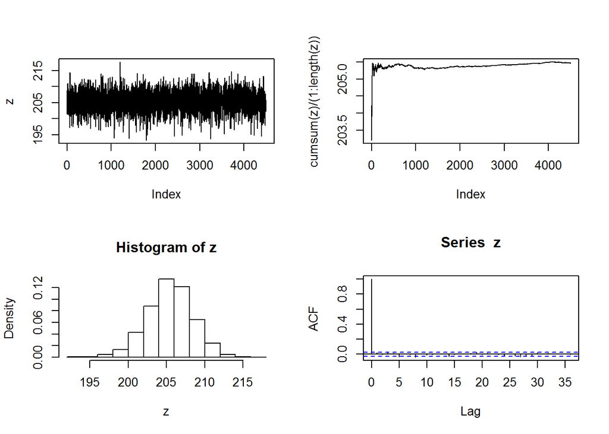

```r
#Cadena
#OpenBUGS
out<-ej2.sim$sims.list

z<-out$mu
par(mfrow=c(2,2))
plot(z,type="l")
plot(cumsum(z)/(1:length(z)),type="l")
hist(z,freq=FALSE)
acf(z)
```

```r
#Resumen (estimadores)
#OpenBUGS
out.sum<-ej2.sim$summary
print(out.sum)
```

```
##               mean        sd      2.5%      25%     50%      75%     97.5%
## mu       205.47244  2.977070 199.30000 203.6000 205.600 207.4000 211.00000
## sig       10.54300  1.939524   7.42795   9.1480  10.295  11.6625  15.01525
## x1       205.33918 11.240333 183.10000 198.1000 205.300 212.6000 227.70000
## deviance  75.62381  1.650611  74.03000  74.4575  75.130  76.2700  79.97149
```

```r
#DIC
#OpenBUGS
out.dic<-ej2.sim$DIC
print(out.dic)
```

```
## [1] 76.98607
```

### Ahora para el inciso b, utilizando una distribución inicial no informativa.

- Utilizamos el archivo **Eje2_b.txt** para describir nuestro modelo:

  ```bash
  model
  {
  #Likelihood
  for (i in 1:n) {
  x[i] ~ dnorm(mu,tau)
  }
  tau<-1/pow(sig,2)
  #Priors
  #----------
  #Inciso b
  mu ~ dnorm(0,0.0001)
  sig ~ dgamma(0.001,0.001)
  #Prediction
  x1 ~ dnorm(mu,tau)
  }
  ```

### Simulamos con el modelo previamente definido y graficamos.

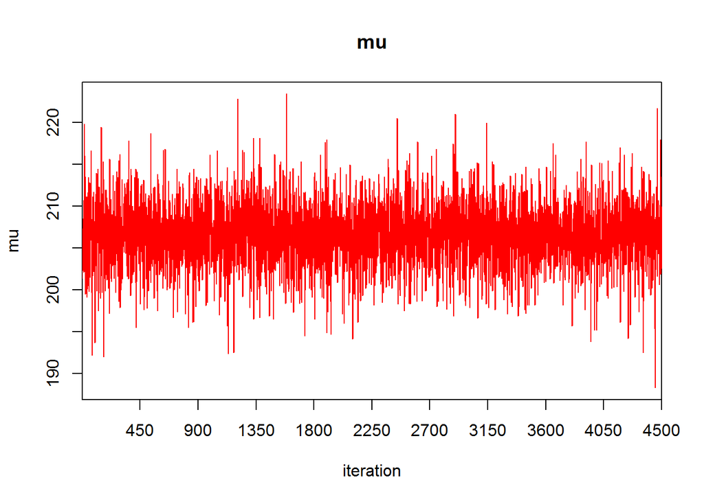

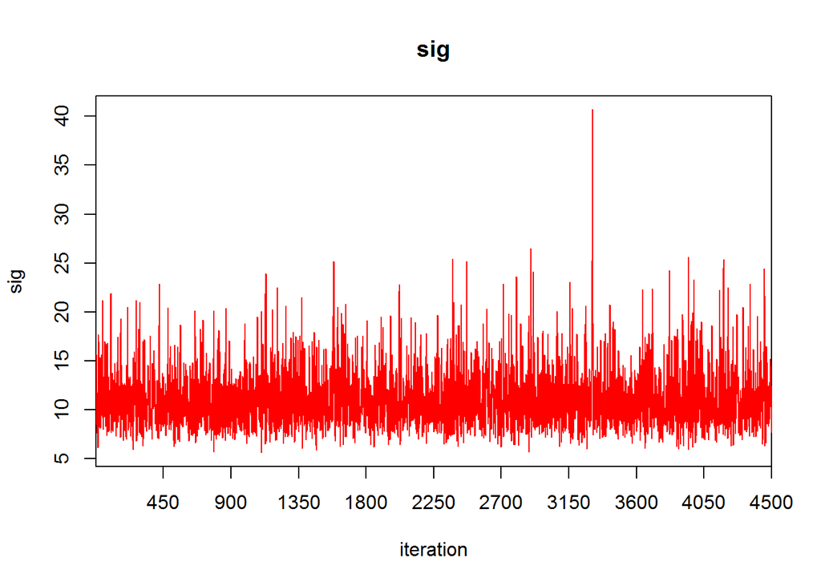

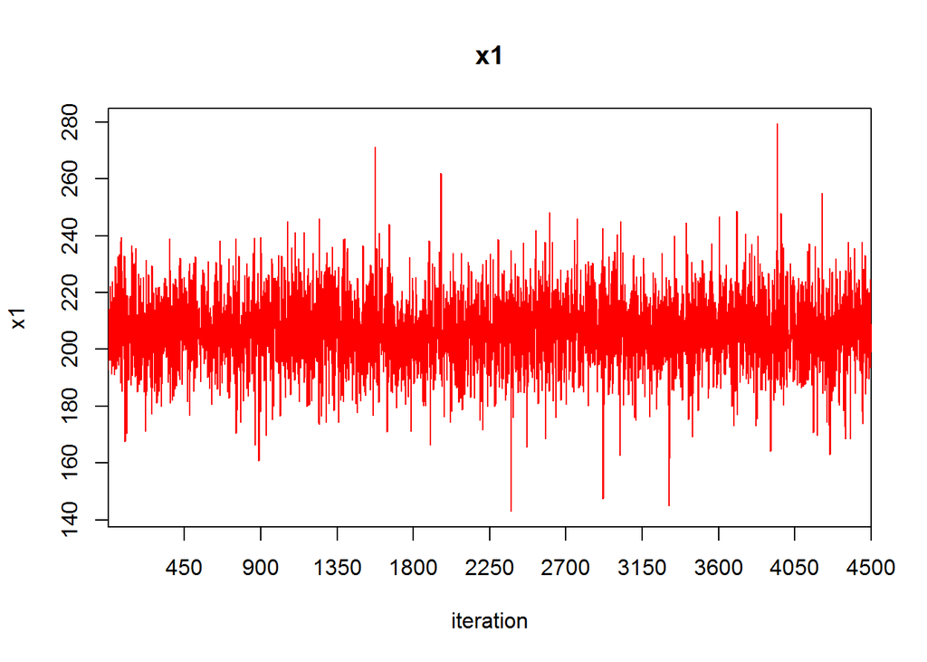

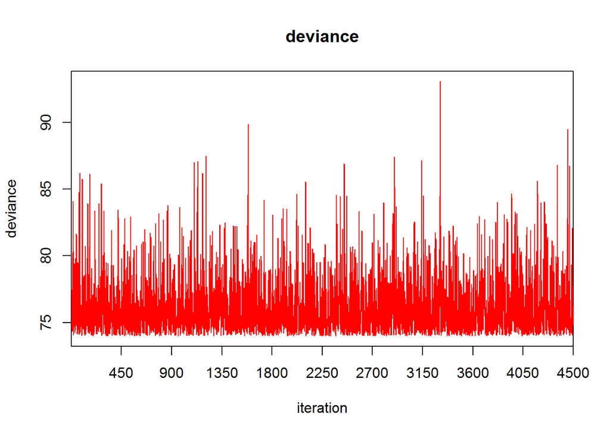

```r
#-Running code-
#OpenBUGS
ej2.sim<-bugs(data,inits,parameters,model.file="Ej2_b.txt",           n.iter=5000,n.chains=1,n.burnin=500)

#-Monitoring chain-

#Traza de la cadena
traceplot(ej2.sim)
```

```r
dev.off()
```

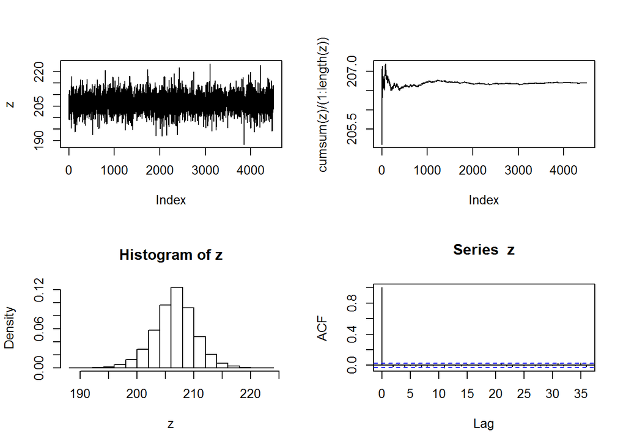

```r
#Cadena
#OpenBUGS
out<-ej2.sim$sims.list

z<-out$mu
par(mfrow=c(2,2))
plot(z,type="l")
plot(cumsum(z)/(1:length(z)),type="l")
hist(z,freq=FALSE)
acf(z)
```

```r
#Resumen (estimadores)
#OpenBUGS
out.sum<-ej2.sim$summary
print(out.sum)
```

```
##               mean        sd       2.5%      25%    50%     75%     97.5%
## mu       206.70280  3.658073 199.000000 204.5000 206.80 208.900 213.90000
## sig       11.22055  2.960489   7.102596   9.1395  10.67  12.650  18.53050
## x1       206.43924 12.116687 182.100000 199.2000 206.30 214.025 230.40000
## deviance  76.16268  2.144395  74.060000  74.6200  75.49  77.000  82.07525
```

```r
#DIC
#OpenBUGS
out.dic<-ej2.sim$DIC
print(out.dic)
```

```
## [1] 78.46189
```